# IODS course project

# About the project

2nd try!

# Regression analysis

*This week my learning was focused on regression analysis. As I am a beginer to statistics, I started with learning theory of the regression analysis, its use and limits, which I found very interesting. Next, I started doing exercices from DataCamp and working on the assignments. Kimmo’s help during workshops was crucial for my progress.*

```r
learning2014 <- read.csv("data/learning2014.csv")

str(learning2014)
```

```
## 'data.frame':    166 obs. of  8 variables:
##  $ X       : int  1 2 3 4 5 6 7 8 9 10 ...
##  $ gender  : Factor w/ 2 levels "F","M": 1 2 1 2 2 1 2 1 2 1 ...
##  $ Age     : int  53 55 49 53 49 38 50 37 37 42 ...
##  $ attitude: num  3.7 3.1 2.5 3.5 3.7 3.8 3.5 2.9 3.8 2.1 ...
##  $ deep    : num  3.58 2.92 3.5 3.5 3.67 ...
##  $ stra    : num  3.38 2.75 3.62 3.12 3.62 ...
##  $ surf    : num  2.58 3.17 2.25 2.25 2.83 ...
##  $ Points  : int  25 12 24 10 22 21 21 31 24 26 ...
```

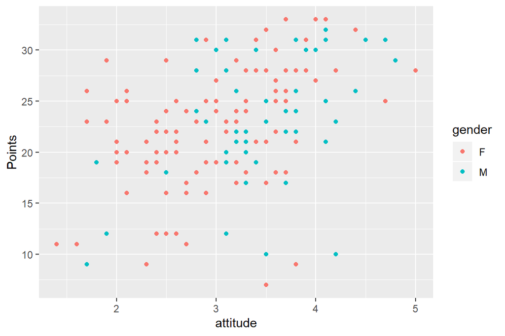

```r
#plot1:
#learning2014
library(ggplot2)
p1 <- ggplot(learning2014, aes(x = attitude, y = Points, col = gender))
p2 <- p1 + geom_point()
p2
```

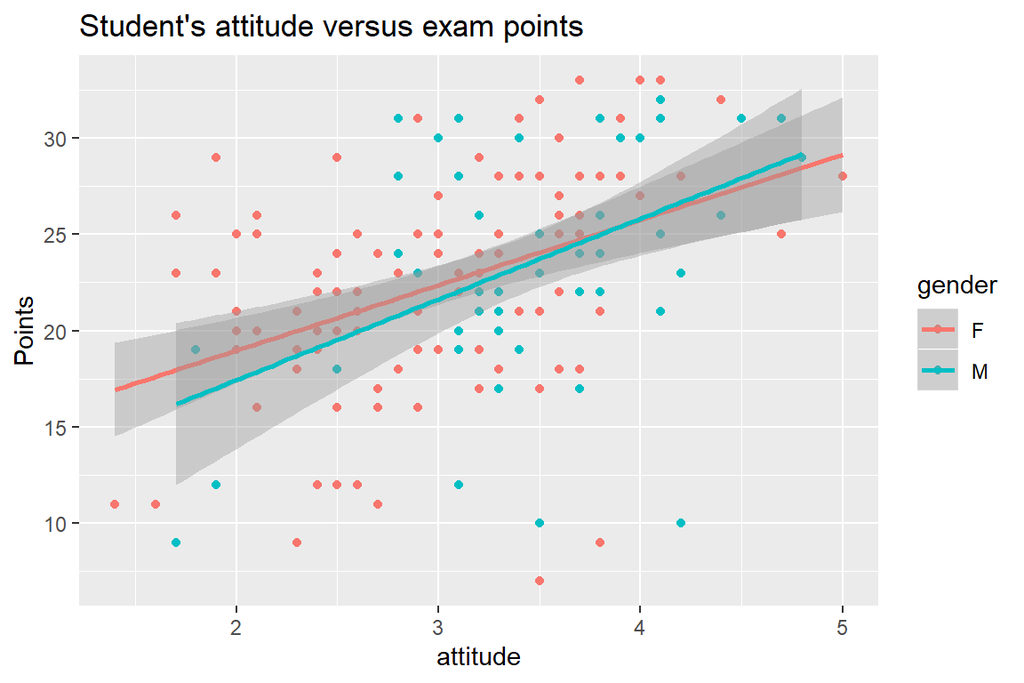

```r
p3 <- p2 + geom_smooth(method = "lm")
p4 <- p3 + ggtitle("Student's attitude versus exam points")
p4
```

- The data was gathered for a research exploring approaches to learning. The responders’ gender, age, and attitude, etc., were taken into account.
- Total of 166 observations of 7 variables. (For some reason at certain point it started showing 8 instead of 7 variables. I worked on that with Kimmo, he said to ignore it). :)
- First, I installed the ggplot2 (packages/install) and initialized plot. Exam points, attitude and gender were taken into account in the analysis.

-The plots are located under the name “plot”, in the “data” folder in my GitHub repository. Edit: for some reason they don’t show there, only codes are visible. The codes are working, and create beautiful models :)

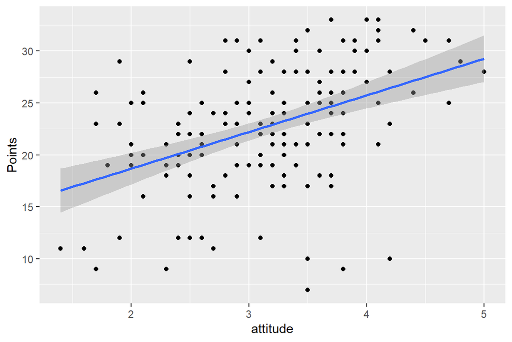

```r
#learning2014
library(ggplot2)
qplot(attitude, Points, data = learning2014) + geom_smooth(method = "lm")
```

```r
my_model <- lm(Points ~ attitude, data = learning2014)
summary(my_model)
```

```
##
## Call:
## lm(formula = Points ~ attitude, data = learning2014)
##
## Residuals:
##      Min       1Q   Median       3Q      Max
## -16.9763  -3.2119   0.4339   4.1534  10.6645
##
## Coefficients:
##             Estimate Std. Error t value Pr(>|t|)
## (Intercept)  11.6372     1.8303   6.358 1.95e-09 ***
## attitude      3.5255     0.5674   6.214 4.12e-09 ***
## ---
## Signif. codes:  0 '***' 0.001 '**' 0.01 '*' 0.05 '.' 0.1 ' ' 1
##
## Residual standard error: 5.32 on 164 degrees of freedom
## Multiple R-squared:  0.1906, Adjusted R-squared:  0.1856
## F-statistic: 38.61 on 1 and 164 DF,  p-value: 4.119e-09
```

Interpretation: it became visible that female participants were able to score higher than male participants when their attitude had lower value. In case of the male participants there is quite clear correlation between attitude and obtained points - statistically the higher the attitude, the higer the points. As for the female participants, the relationship between these vaiables is weaker. More participants scored better than predicted. Predictably there were cases of low points when the attitude was low, as well as there were high scores when the attitude was high. The statistical test is expressed by the slope of the line. In the performed analysis, it is different than 0, proving the usabilty of the model.

R-squared of the model answers the question how well the model represents the data. Put simply, it is defined by the difference between observed value (data; dots on the plot) and fitted value (predicting line; errors; residue). As Tuomo Nieminen explains, “the model is found by minimising the sum of squared residuals”.

```r
head(learning2014) # just to see the 6 first lines
```

```
##   X gender Age attitude     deep  stra     surf Points
## 1 1      F  53      3.7 3.583333 3.375 2.583333     25
## 2 2      M  55      3.1 2.916667 2.750 3.166667     12
## 3 3      F  49      2.5 3.500000 3.625 2.250000     24
## 4 4      M  53      3.5 3.500000 3.125 2.250000     10
## 5 5      M  49      3.7 3.666667 3.625 2.833333     22
## 6 6      F  38      3.8 4.750000 3.625 2.416667     21
```

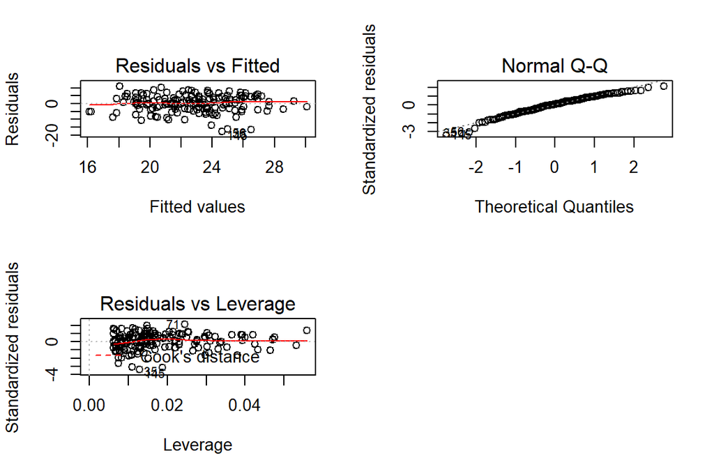

```r
my_model2 <- lm(Points ~ attitude + stra, data = learning2014)
par(mfrow = c(2,2))
plot(my_model2, which = c(1, 2, 5))
```

Residual vs. Fitted values verifies the assumptions of the model.

the Normal Q-Q -here it confirms that the errors are normally distributed.

Residuals vs. Leverage shows which observations have impact on the model that could be defined as “unusually high”.

# Chapter 3

*Logistic regression*

```r
url <- "http://s3.amazonaws.com/assets.datacamp.com/production/course_2218/datasets"
url_math <- paste(url, "student-mat.csv", sep = "/")
url_math
```

```
## [1] "http://s3.amazonaws.com/assets.datacamp.com/production/course_2218/datasets/student-mat.csv"
```

```r
math <- read.table(url_math, sep = ";" , header=TRUE)
url_por <- paste(url, "student-por.csv", sep ="/")
url_por
```

```
## [1] "http://s3.amazonaws.com/assets.datacamp.com/production/course_2218/datasets/student-por.csv"
```

```r
por <- read.table(url_por, sep = ";", header = TRUE)
colnames(math)
```

```
##  [1] "school"     "sex"        "age"        "address"    "famsize"
##  [6] "Pstatus"    "Medu"       "Fedu"       "Mjob"       "Fjob"
## [11] "reason"     "guardian"   "traveltime" "studytime"  "failures"
## [16] "schoolsup"  "famsup"     "paid"       "activities" "nursery"
## [21] "higher"     "internet"   "romantic"   "famrel"     "freetime"
## [26] "goout"      "Dalc"       "Walc"       "health"     "absences"
## [31] "G1"         "G2"         "G3"
```

```r
colnames(por)
```

```
##  [1] "school"     "sex"        "age"        "address"    "famsize"
##  [6] "Pstatus"    "Medu"       "Fedu"       "Mjob"       "Fjob"
## [11] "reason"     "guardian"   "traveltime" "studytime"  "failures"
## [16] "schoolsup"  "famsup"     "paid"       "activities" "nursery"
## [21] "higher"     "internet"   "romantic"   "famrel"     "freetime"
## [26] "goout"      "Dalc"       "Walc"       "health"     "absences"
## [31] "G1"         "G2"         "G3"
```

#Description: The data refers to the achievements of students of two Portugese schools (secondary education). The data includes information concerning students’ grades, their background, alcohol consumption level etc.

#Hypothesis: #1. The inhabitants of rural areas consume more alcohol that those living in urban zones. #2. Age-gender relationship. The alcohol consumption is higher amongst men than women. Men start drinking earlier that women. #3. The extra-curricular activities can be correlated with the lower level of alcohol consumption. #4. Going out can be associated with higher level of drinking.

```r
# math and por are available

# access the dplyr library
library(dplyr)
# common columns to use as identifiers
join_by <- c("school","sex","age","address","famsize","Pstatus","Medu","Fedu","Mjob","Fjob","reason","nursery","internet")

# join the two datasets by the selected identifiers
math_por <- inner_join(math, por, by = join_by, suffix = c(".math", ".por"))

# see the new column names
colnames(math_por)
```

```
##  [1] "school"          "sex"             "age"             "address"
##  [5] "famsize"         "Pstatus"         "Medu"            "Fedu"
##  [9] "Mjob"            "Fjob"            "reason"          "guardian.math"
## [13] "traveltime.math" "studytime.math"  "failures.math"   "schoolsup.math"
## [17] "famsup.math"     "paid.math"       "activities.math" "nursery"
## [21] "higher.math"     "internet"        "romantic.math"   "famrel.math"
## [25] "freetime.math"   "goout.math"      "Dalc.math"       "Walc.math"
## [29] "health.math"     "absences.math"   "G1.math"         "G2.math"
## [33] "G3.math"         "guardian.por"    "traveltime.por"  "studytime.por"
## [37] "failures.por"    "schoolsup.por"   "famsup.por"      "paid.por"
## [41] "activities.por"  "higher.por"      "romantic.por"    "famrel.por"
## [45] "freetime.por"    "goout.por"       "Dalc.por"        "Walc.por"
## [49] "health.por"      "absences.por"    "G1.por"          "G2.por"
## [53] "G3.por"
```

```r
# glimpse at the data
glimpse(math_por)
```

```
## Observations: 382
## Variables: 53
## $ school          <fct> GP, GP, GP, GP, GP, GP, GP, GP, GP, GP, GP, GP, GP,...
## $ sex             <fct> F, F, F, F, F, M, M, F, M, M, F, F, M, M, M, F, F, ...
## $ age             <int> 18, 17, 15, 15, 16, 16, 16, 17, 15, 15, 15, 15, 15,...
## $ address         <fct> U, U, U, U, U, U, U, U, U, U, U, U, U, U, U, U, U, ...
## $ famsize         <fct> GT3, GT3, LE3, GT3, GT3, LE3, LE3, GT3, LE3, GT3, G...
## $ Pstatus         <fct> A, T, T, T, T, T, T, A, A, T, T, T, T, T, A, T, T, ...
## $ Medu            <int> 4, 1, 1, 4, 3, 4, 2, 4, 3, 3, 4, 2, 4, 4, 2, 4, 4, ...
## $ Fedu            <int> 4, 1, 1, 2, 3, 3, 2, 4, 2, 4, 4, 1, 4, 3, 2, 4, 4, ...
## $ Mjob            <fct> at_home, at_home, at_home, health, other, services,...
## $ Fjob            <fct> teacher, other, other, services, other, other, othe...
## $ reason          <fct> course, course, other, home, home, reputation, home...
## $ guardian.math   <fct> mother, father, mother, mother, father, mother, mot...
## $ traveltime.math <int> 2, 1, 1, 1, 1, 1, 1, 2, 1, 1, 1, 3, 1, 2, 1, 1, 1, ...
```

[output cut: 40 more lines]

```r
# dplyr, math_por, join_by are available

# print out the column names of 'math_por'
colnames(math_por)
```

```
##  [1] "school"          "sex"             "age"             "address"
##  [5] "famsize"         "Pstatus"         "Medu"            "Fedu"
##  [9] "Mjob"            "Fjob"            "reason"          "guardian.math"
## [13] "traveltime.math" "studytime.math"  "failures.math"   "schoolsup.math"
## [17] "famsup.math"     "paid.math"       "activities.math" "nursery"
## [21] "higher.math"     "internet"        "romantic.math"   "famrel.math"
## [25] "freetime.math"   "goout.math"      "Dalc.math"       "Walc.math"
## [29] "health.math"     "absences.math"   "G1.math"         "G2.math"
## [33] "G3.math"         "guardian.por"    "traveltime.por"  "studytime.por"
## [37] "failures.por"    "schoolsup.por"   "famsup.por"      "paid.por"
## [41] "activities.por"  "higher.por"      "romantic.por"    "famrel.por"
## [45] "freetime.por"    "goout.por"       "Dalc.por"        "Walc.por"
## [49] "health.por"      "absences.por"    "G1.por"          "G2.por"
## [53] "G3.por"
```

```r
# create a new data frame with only the joined columns
alc <- select(math_por, one_of(join_by))

# columns that were not used for joining the data
notjoined_columns <- colnames(math)[!colnames(math) %in% join_by]

# print out the columns not used for joining
notjoined_columns
```

```
##  [1] "guardian"   "traveltime" "studytime"  "failures"   "schoolsup"
##  [6] "famsup"     "paid"       "activities" "higher"     "romantic"
## [11] "famrel"     "freetime"   "goout"      "Dalc"       "Walc"
## [16] "health"     "absences"   "G1"         "G2"         "G3"
```

```r
# for every column name not used for joining...
for(column_name in notjoined_columns) {
  # select two columns from 'math_por' with the same original name
  two_columns <- select(math_por, starts_with(column_name))
  # select the first column vector of those two columns
  first_column <- select(two_columns, 1)[[1]]

  # if that first column  vector is numeric...
  if(is.numeric(first_column)) {
    # take a rounded average of each row of the two columns and
    # add the resulting vector to the alc data frame
    alc[column_name] <- round(rowMeans(two_columns))
  } else { # else if it's not numeric...
    # add the first column vector to the alc data frame
    alc[column_name] <- first_column
  }
}

# glimpse at the new combined data
glimpse(alc)
```

```
## Observations: 382
## Variables: 33
## $ school     <fct> GP, GP, GP, GP, GP, GP, GP, GP, GP, GP, GP, GP, GP, GP, ...
## $ sex        <fct> F, F, F, F, F, M, M, F, M, M, F, F, M, M, M, F, F, F, M,...
## $ age        <int> 18, 17, 15, 15, 16, 16, 16, 17, 15, 15, 15, 15, 15, 15, ...
## $ address    <fct> U, U, U, U, U, U, U, U, U, U, U, U, U, U, U, U, U, U, U,...
## $ famsize    <fct> GT3, GT3, LE3, GT3, GT3, LE3, LE3, GT3, LE3, GT3, GT3, G...
## $ Pstatus    <fct> A, T, T, T, T, T, T, A, A, T, T, T, T, T, A, T, T, T, T,...
## $ Medu       <int> 4, 1, 1, 4, 3, 4, 2, 4, 3, 3, 4, 2, 4, 4, 2, 4, 4, 3, 3,...
## $ Fedu       <int> 4, 1, 1, 2, 3, 3, 2, 4, 2, 4, 4, 1, 4, 3, 2, 4, 4, 3, 2,...
## $ Mjob       <fct> at_home, at_home, at_home, health, other, services, othe...
## $ Fjob       <fct> teacher, other, other, services, other, other, other, te...
## $ reason     <fct> course, course, other, home, home, reputation, home, hom...
## $ nursery    <fct> yes, no, yes, yes, yes, yes, yes, yes, yes, yes, yes, ye...
## $ internet   <fct> no, yes, yes, yes, no, yes, yes, no, yes, yes, yes, yes,...
```

[output cut: 20 more lines]

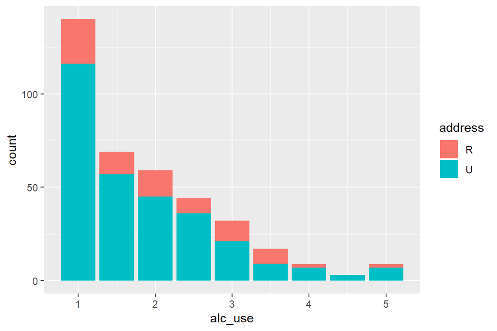

```r
# alc is available

# access the 'tidyverse' packages dplyr and ggplot2
library(dplyr); library(ggplot2)

# define a new column alc_use by combining weekday and weekend alcohol use
alc <- mutate(alc, alc_use = (Dalc + Walc) / 2)

# initialize a plot of alcohol use
g1 <- ggplot(data = alc, aes(x = alc_use, fill = address))

# define the plot as a bar plot and draw it
g1 + geom_bar()
```

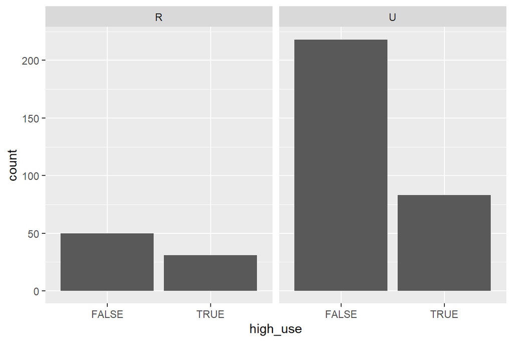

```r
# define a new logical column 'high_use'
alc <- mutate(alc, high_use = alc_use > 2)

# initialize a plot of 'high_use'
g2 <- ggplot(alc, aes(high_use))

# draw a bar plot of high_use by
g2 + facet_wrap("address") + geom_bar()
```